#### Language: English, Nr of Labels: 7000 Labels

For the English dataset, we observed higher macro F1 rates over all the nine trained classifiers when we used TF-IDFs as the instances features. TF-IDFs are more powerful representative features than simply using the incidence of terms as features. The expreiments show that label Powerset combined with random forest recorded the best result for the two type of features(TF-IDF and Incidence), whereas the label powerset method combined with XGB preformed the worst as shown in the following figures:

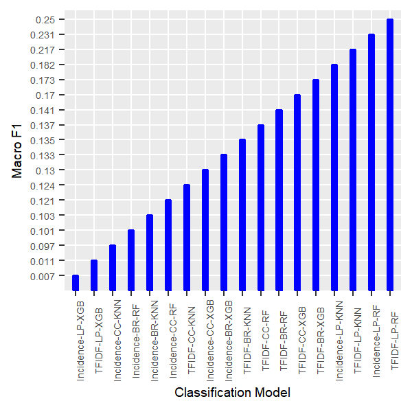

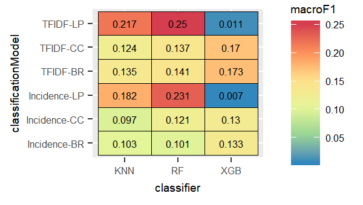

In the following sections we will display the results in detail for each feature separately.

#### Language: English, Feature: TF-IDF, Nr of Labels: 7000 Labels

##### Label Powerset

According to the following figures, Label Powerset with the K nearest neighbour and random forest performed the best, however, with XGBoost, the perfomance was the worst.

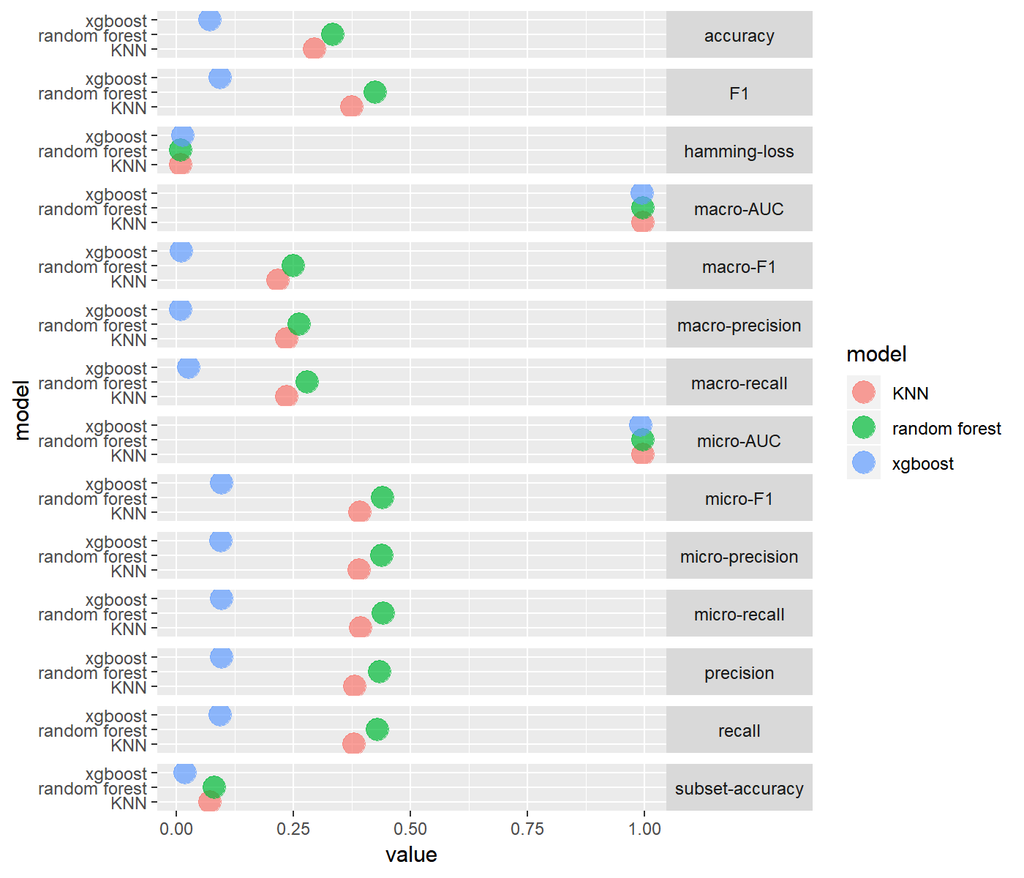

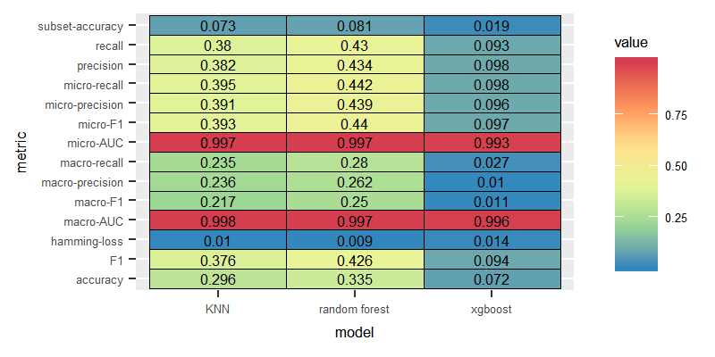

##### Binary Relevance

We compared the three models where the labels are assumed to be independent. Binary relevance produced the best classifier combined with XGBoost.

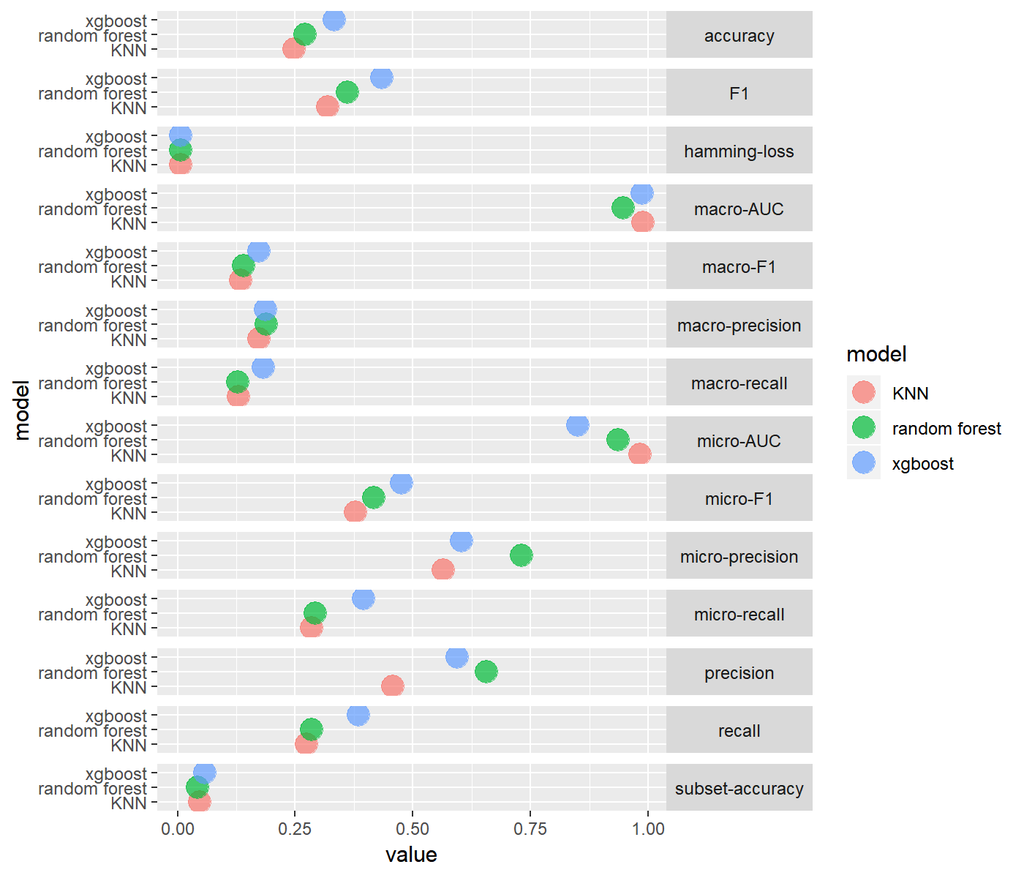

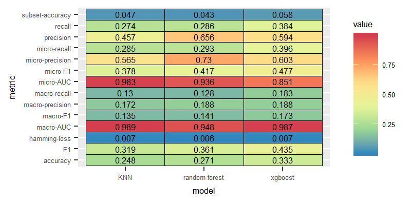

##### Classifier Chains

Similar to the Binary Relevance method, Classifier Chain performed the best with the XGBoost classifier.

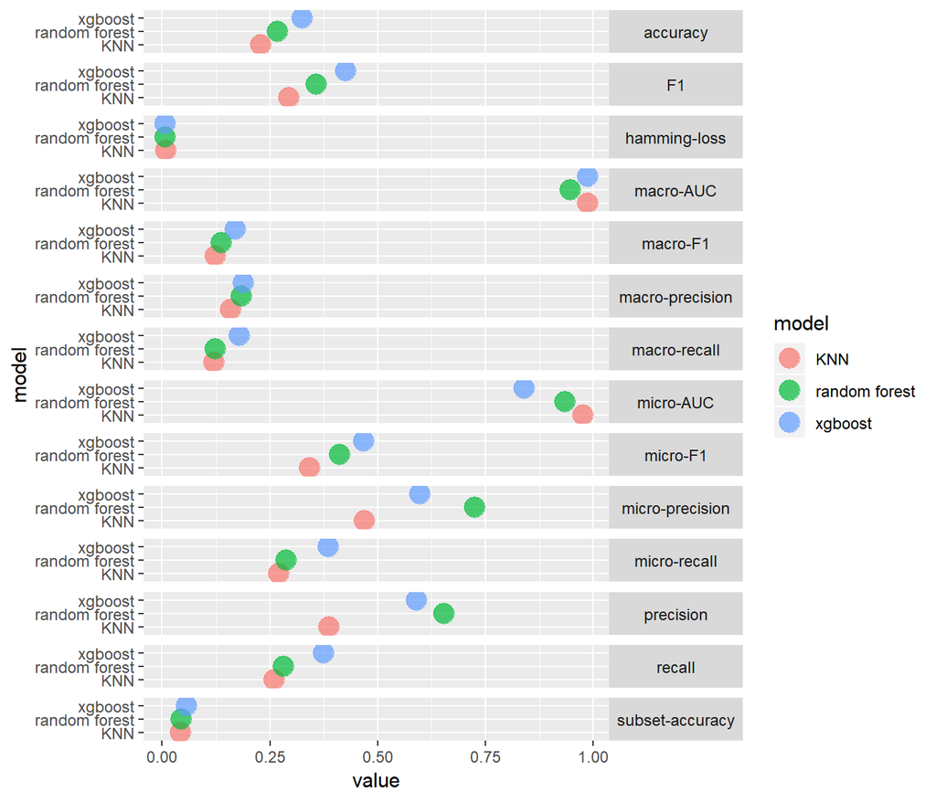

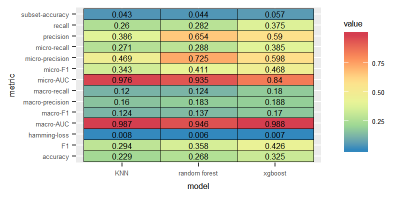

#### Language: English, Feature: Incidence, Nr of Labels: 7000 Labels

We wanted to test the performance of the models in case of employing more naive features as the incedence of terms. For the English language, the experiments showed similar pattern as the case of TFIDF features, where the Label powerset with the random forest classifier scored the highest macro F1 value. Nevertheless, having the incedince of terms as features did not score better performance than the TFIDF features.

##### Label Powerset

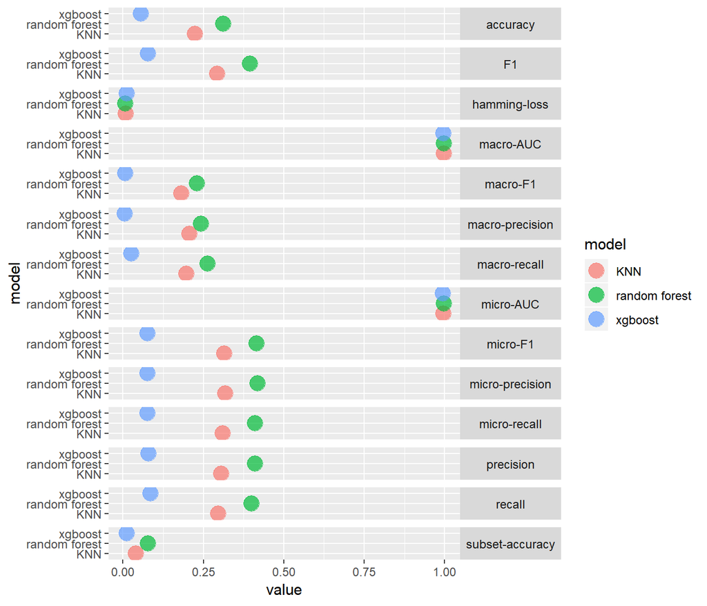

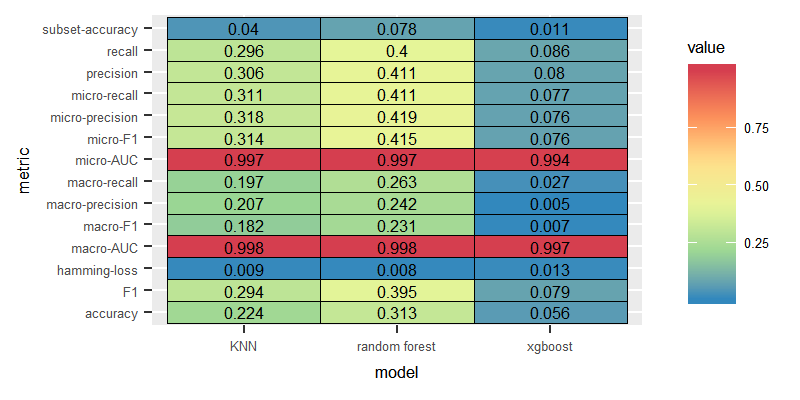

##### Binary Relevance

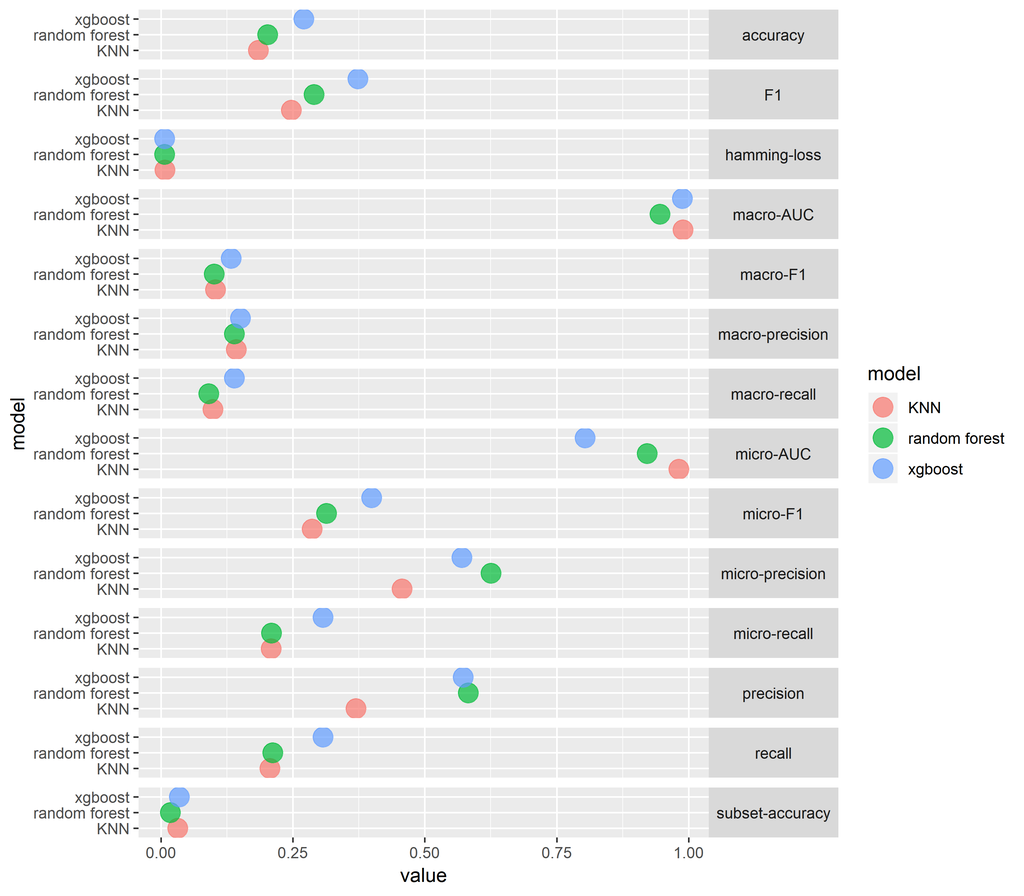

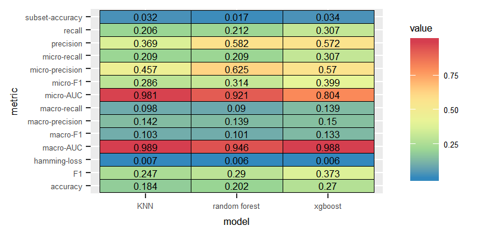

##### Classifier Chains

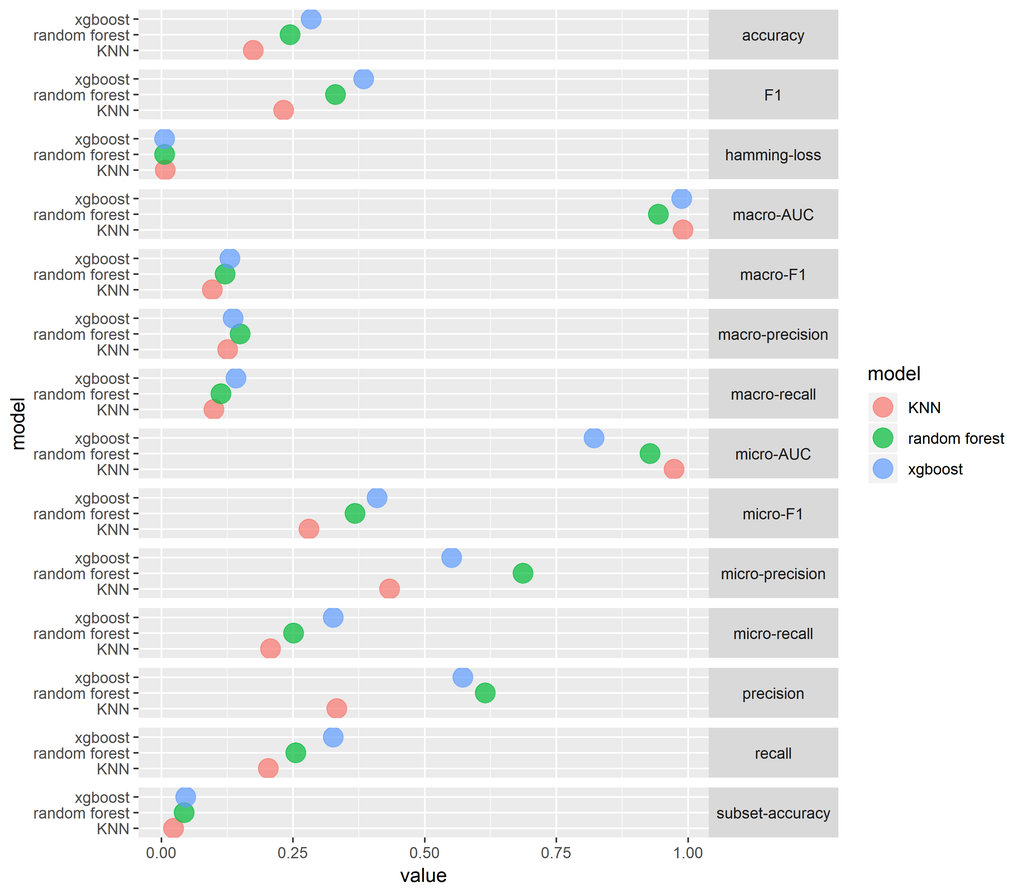

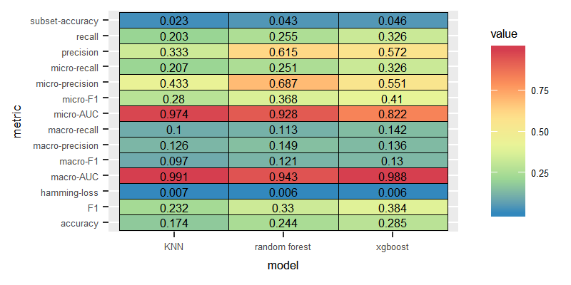

#### Language: German, Nr of Labels: 7000 Labels

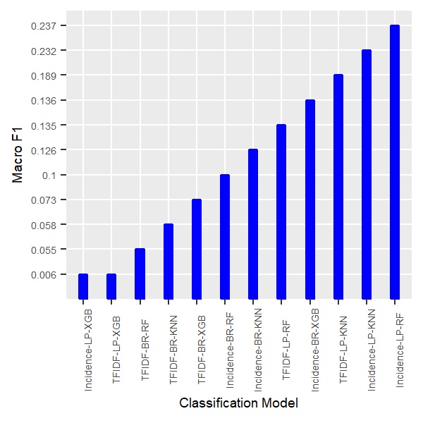

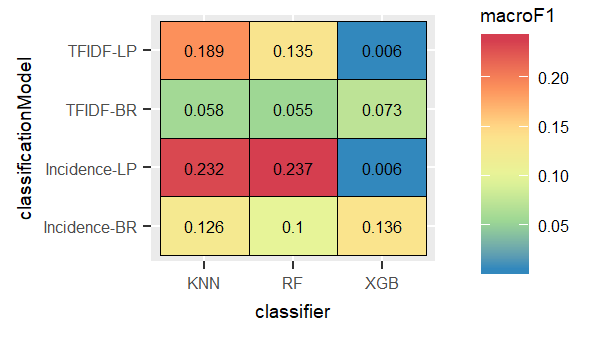

In the following sections we will display the results of the experimencts ran on the German dataset in detail for each feature separately.

#### Language: German, Feature: TF-IDF, Nr of Labels: 7000 Labels

Extracting TFIDFs is computentially expensive. Comparing the low performance of the classifiers to the better performance of classifiers trained on the incidence of terms, lead us to qualify the terms incidences as more effective features to train the classifiers on.

##### Label Powerset

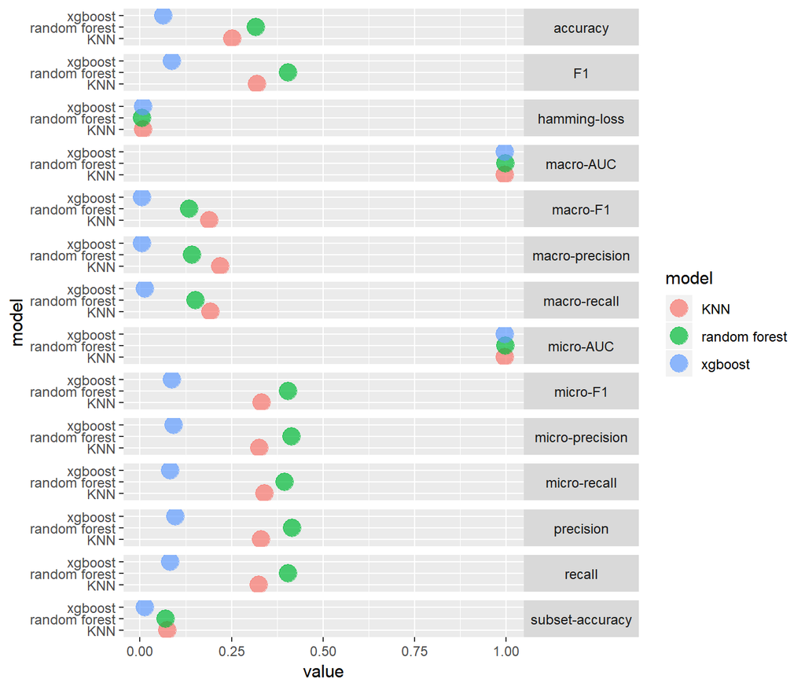